### Q1.Segment respondents based on the Partworth data (use any unsupervised learning technique).

#### Solution:

```r
#Load Data

partdata <- read.csv("C://Users//AKANKSHA//Desktop//ISB CBA//Marketing Analytics//Partworth Data.csv", header = TRUE, sep = ",")
#partdata[1] <- NULL
head(partdata)
```

```
##   Respondents European Canadian Japanese X6.19 X5.49 X4.79
## 1        6861        0        8       12     0    16    23
## 2        4129        1        4        0     8     0    51
## 3        4393       19        0       15    16     0     3
## 4         445        0       17       19     0    19    21
## 5        7393       20        0        4     9     3     0
## 6         964       17        3        0     6    14     0
##   Rich.full.bodied Regular Crisp.and.clear Strong Mild Very.mild Full
## 1                8       0              10     10    6         0    0
## 2                8       0               4      6    0         2    2
## 3               31       0              20      0    7        13    6
## 4                0      12               1      0    5        11    0
## 5                0       0              11      0   13         6    9
## 6                0       3              24     11    0         6    6
##   Regular.1 Low Six.12Oz.Large Six.12Oz.Small Four.16Oz Green.Label
## 1        21  13              4              0        11           9
## 2         6   0              0             12        10          13
## 3         0   8              0              4         8           1
## 4        14  17              0              0        12           0
## 5         0  23             17              0         8           0
## 6         8   0              0              6        14           0
##   Brown.Label Brown.Painted
## 1           0            13
## 2           5             0
## 3           5             0
## 4           1             9
## 5           6             3
## 6          12             7
```

```r
dim(partdata)
```

```
## [1] 317  22
```

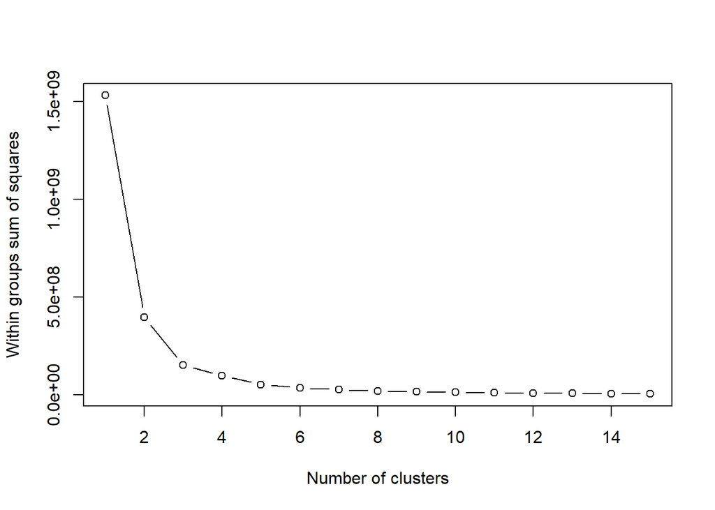

```r
normalized_data <- scale(partdata)
Cluster_Variability <- matrix(nrow=15, ncol=1)
for (i in 1:15) Cluster_Variability[i] <- kmeans(partdata,centers=i,iter.max=20, nstart=4)$tot.withinss
plot(1:15, Cluster_Variability, type="b", xlab="Number of clusters", ylab="Within groups sum of squares") ## Elbow curve or Scree plot
```

### From the above we can observe that we get an elbow at k=2, so we will perform k means clustering by taking 2 clusters.

```r
fit1 <- kmeans(partdata, centers=2, iter.max=20, nstart=4)
fit1
```

```
## K-means clustering with 2 clusters of sizes 133, 184
##
## Cluster means:
##   Respondents European Canadian Japanese    X6.19    X5.49    X4.79
## 1    1965.353 10.93233 5.338346 9.954887 3.736842 7.007519 6.383459
## 2    5798.549 12.19022 4.576087 7.885870 4.608696 6.130435 6.070652
##   Rich.full.bodied  Regular Crisp.and.clear   Strong     Mild Very.mild
## 1         10.49624 2.015038        8.744361 4.263158 11.84211  5.789474
## 2         11.39130 1.603261       10.179348 3.065217 12.93478  5.945652
##       Full Regular.1      Low Six.12Oz.Large Six.12Oz.Small Four.16Oz
## 1 7.639098  7.646617 10.17293       10.04511       2.406015  7.022556
## 2 9.005435  5.961957 10.19022       10.70109       2.663043  6.826087
##   Green.Label Brown.Label Brown.Painted
## 1    3.548872    5.616541      8.037594
## 2    3.168478    5.630435      7.250000
##
## Clustering vector:
##   [1] 2 2 2 1 2 1 2 1 2 2 2 1 2 1 2 2 2 2 1 1 2 2 2 2 2 1 2 2 2 2 1 2 1 1 2
##  [36] 2 2 1 1 2 1 2 2 2 2 1 1 2 2 2 2 2 2 2 1 1 2 1 1 2 1 1 1 1 1 2 1 1 2 2
##  [71] 1 1 1 2 1 1 2 1 1 1 1 2 1 1 1 1 1 1 2 2 2 2 1 1 1 2 2 2 1 2 2 1 2 1 1
## [106] 2 2 1 2 2 2 1 1 1 1 2 2 2 1 2 2 2 1 1 2 1 2 1 2 2 2 2 2 1 1 1 2 2 2 2
## [141] 2 1 2 1 2 1 1 2 2 1 1 1 1 2 2 2 2 1 2 2 2 2 2 2 1 2 1 2 2 1 1 1 1 1 2
## [176] 1 1 2 2 1 2 2 2 1 2 2 1 2 1 1 1 2 2 1 2 2 1 1 2 1 1 2 1 2 1 1 1 2 1 1
## [211] 2 1 2 2 2 2 1 2 1 1 2 1 1 2 2 1 2 2 2 2 1 2 1 2 1 1 1 1 2 1 2 2 2 2 2
## [246] 2 1 2 1 2 1 2 1 2 1 2 1 2 1 1 2 2 2 2 2 2 2 2 1 2 2 2 2 1 2 2 2 2 2 1
## [281] 2 1 2 2 2 2 2 2 2 1 2 1 2 1 2 2 1 2 2 1 1 2 2 2 2 2 1 2 1 2 2 2 2 1 2
## [316] 1 2
##
## Within cluster sum of squares by cluster:
## [1] 188934109 208913852
##  (between_SS / total_SS =  74.0 %)
##
## Available components:
##
## [1] "cluster"      "centers"      "totss"        "withinss"
## [5] "tot.withinss" "betweenss"    "size"         "iter"
## [9] "ifault"
```

### Observing the different attributes,

```r
fit1$cluster
```

```
##   [1] 2 2 2 1 2 1 2 1 2 2 2 1 2 1 2 2 2 2 1 1 2 2 2 2 2 1 2 2 2 2 1 2 1 1 2
##  [36] 2 2 1 1 2 1 2 2 2 2 1 1 2 2 2 2 2 2 2 1 1 2 1 1 2 1 1 1 1 1 2 1 1 2 2
##  [71] 1 1 1 2 1 1 2 1 1 1 1 2 1 1 1 1 1 1 2 2 2 2 1 1 1 2 2 2 1 2 2 1 2 1 1
## [106] 2 2 1 2 2 2 1 1 1 1 2 2 2 1 2 2 2 1 1 2 1 2 1 2 2 2 2 2 1 1 1 2 2 2 2
## [141] 2 1 2 1 2 1 1 2 2 1 1 1 1 2 2 2 2 1 2 2 2 2 2 2 1 2 1 2 2 1 1 1 1 1 2
## [176] 1 1 2 2 1 2 2 2 1 2 2 1 2 1 1 1 2 2 1 2 2 1 1 2 1 1 2 1 2 1 1 1 2 1 1
## [211] 2 1 2 2 2 2 1 2 1 1 2 1 1 2 2 1 2 2 2 2 1 2 1 2 1 1 1 1 2 1 2 2 2 2 2
## [246] 2 1 2 1 2 1 2 1 2 1 2 1 2 1 1 2 2 2 2 2 2 2 2 1 2 2 2 2 1 2 2 2 2 2 1
## [281] 2 1 2 2 2 2 2 2 2 1 2 1 2 1 2 2 1 2 2 1 1 2 2 2 2 2 1 2 1 2 2 2 2 1 2
## [316] 1 2
```

```r
fit1$centers
```

```
##   Respondents European Canadian Japanese    X6.19    X5.49    X4.79
## 1    1965.353 10.93233 5.338346 9.954887 3.736842 7.007519 6.383459
## 2    5798.549 12.19022 4.576087 7.885870 4.608696 6.130435 6.070652
##   Rich.full.bodied  Regular Crisp.and.clear   Strong     Mild Very.mild
## 1         10.49624 2.015038        8.744361 4.263158 11.84211  5.789474
## 2         11.39130 1.603261       10.179348 3.065217 12.93478  5.945652
##       Full Regular.1      Low Six.12Oz.Large Six.12Oz.Small Four.16Oz
## 1 7.639098  7.646617 10.17293       10.04511       2.406015  7.022556
## 2 9.005435  5.961957 10.19022       10.70109       2.663043  6.826087
##   Green.Label Brown.Label Brown.Painted
## 1    3.548872    5.616541      8.037594
## 2    3.168478    5.630435      7.250000
```

```r
fit1$totss
```

```
## [1] 1532160497
```

```r
fit1$withinss
```

```
## [1] 188934109 208913852
```

```r
fit1$tot.withinss
```

```
## [1] 397847961
```

```r
fit1$betweenss
```

```
## [1] 1134312536
```

```r
fit1$size
```

```
## [1] 133 184
```

```r
fit1$iter
```

```
## [1] 1
```

### From the above, we can see that the respondents can be divided into two segments:

#### In terms of Aftertaste, Cluster 1 prefers Strong taste while Cluster 2 prefers Mild taste. Both have almost similar prefernce towards Very mild taste.

#### Cluster 1 consumes less Full calories when compared to Cluster 2, although Cluster 1 consumes more Regular calories when compared to Cluster 2. Both prefer low calories equally.

#### Cluster 1 prefers Four 16oz while both prefer 12 oz equally.

#### Cluster 1 prefers Brown painted glass more than Cluster 2 while, both cluster 1 and cluster 2 prefer Brown and Green glass almost equally.

### Now, proceeding further and saving the CSV,

```r
partdataWithClusterMember <- cbind(partdata, fit1$cluster) # append cluster membership
head(partdataWithClusterMember)
```

```
##   Respondents European Canadian Japanese X6.19 X5.49 X4.79
## 1        6861        0        8       12     0    16    23
## 2        4129        1        4        0     8     0    51
## 3        4393       19        0       15    16     0     3
## 4         445        0       17       19     0    19    21
## 5        7393       20        0        4     9     3     0
## 6         964       17        3        0     6    14     0
##   Rich.full.bodied Regular Crisp.and.clear Strong Mild Very.mild Full
## 1                8       0              10     10    6         0    0
## 2                8       0               4      6    0         2    2
## 3               31       0              20      0    7        13    6
## 4                0      12               1      0    5        11    0
## 5                0       0              11      0   13         6    9
## 6                0       3              24     11    0         6    6
##   Regular.1 Low Six.12Oz.Large Six.12Oz.Small Four.16Oz Green.Label
## 1        21  13              4              0        11           9
## 2         6   0              0             12        10          13
## 3         0   8              0              4         8           1
## 4        14  17              0              0        12           0
## 5         0  23             17              0         8           0
## 6         8   0              0              6        14           0
##   Brown.Label Brown.Painted fit1$cluster
## 1           0            13            2
## 2           5             0            2
## 3           5             0            2
## 4           1             9            1
## 5           6             3            2
## 6          12             7            1
```

```r
write.csv(partdataWithClusterMember,file="partdataWithClusterMember.csv")

getwd()
```

```
## [1] "C:/Users/AKANKSHA/Desktop/ISB CBA/Marketing Analytics"
```